# Reading the CSV

# Finding the usage of social media accross the data set

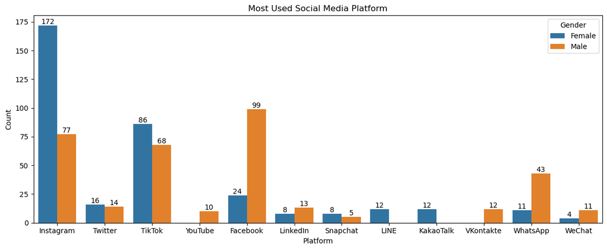

```python
plt.figure(figsize=(12, 5))    # Correct keyword is `figsize`
ax = sns.countplot(data=df_cleaned, x='Most_Used_Platform', hue='Gender')
#plt.xticks(rotation=45)
for bar in ax.containers:
    ax.bar_label(bar)
plt.title("Most Used Social Media Platform")
plt.xlabel("Platform")
plt.ylabel("Count")
plt.tight_layout()
plt.show()
```

#### We can see that Male tends to use Youtube, Linkedln,Facebook, Vkontake, Whatsapp, Wechat with Faceook topping the list

#### While Females have a more trend in uing Instagram, KakaoTalk, TikTok whith Instagram Topping

```python
df_cleaned.groupby('Gender')['Avg_Daily_Usage_Hours'].mean()
```

```
Gender
Female    5.011048
Male      4.826136
Name: Avg_Daily_Usage_Hours, dtype: float64
```

#### checking the avg usage time per gender

```python
df_cleaned.groupby('Gender')['Avg_Daily_Usage_Hours'].median()
```

```
Gender
Female    4.8
Male      4.7
Name: Avg_Daily_Usage_Hours, dtype: float64
```

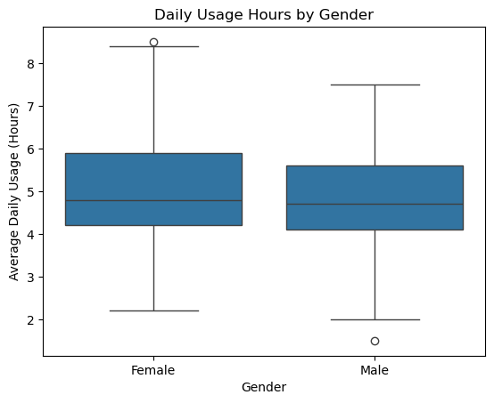

```python
sns.boxplot(data=df_cleaned, x='Gender', y='Avg_Daily_Usage_Hours')
plt.title("Daily Usage Hours by Gender")
plt.xlabel("Gender")
plt.ylabel("Average Daily Usage (Hours)")
plt.show()
```

Also the outlier range for male starts from roungly 7.5 but in case of female the data points went above 8.3 roughly

## Checking the Avg Score of Addiction accross Genders

```python
df_cleaned.groupby('Gender')['Addicted_Score'].mean()
```

```
Gender
Female    6.515581
Male      6.357955
Name: Addicted_Score, dtype: float64
```

```python
df_cleaned.groupby('Gender')['Addicted_Score'].median()
```

```
Gender
Female    7.0
Male      7.0
Name: Addicted_Score, dtype: float64
```

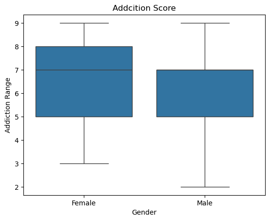

```python
ax=sns.boxplot(data=df_cleaned,x='Gender',y='Addicted_Score')
plt.title("Addcition Score")
plt.xlabel("Gender")
plt.ylabel("Addiction Range")
plt.show()
```

#### the lower IOR range is far more in men compared to female

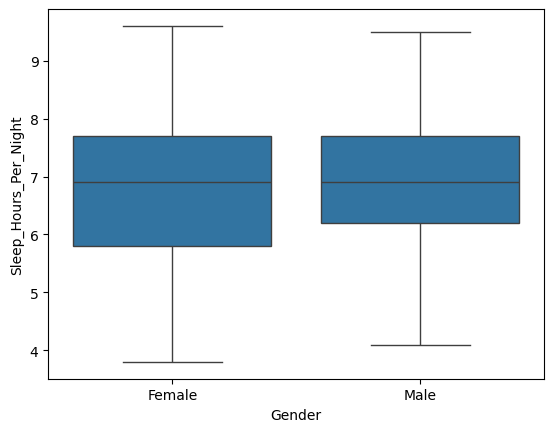

```python
sns.boxplot(data=df_cleaned, x='Gender', y='Sleep_Hours_Per_Night')
```

## As we can see that the outileris an Univeriate Outlier on in "AVG_USAGE_PER_DAY" that is why it is safe tokeepin the analysis

## Getting to know the Demograph

### Now I have to check which countries have participated more

```python
df_cleaned['Country'].value_counts().head(10)
```

```
Country
India          53
USA            40
Canada         34
Denmark        27
Ireland        27
Turkey         27
Mexico         27
Spain          27
France         27
Switzerland    27
Name: count, dtype: int64
```

### A lot of countries have only 1 data so grouping on the basis of country won't be valid

### Relationship related to Using of Social Media

```python
df_cleaned['Relationship_Status'].unique()
```

```
array(['In Relationship', 'Single', 'Complicated'], dtype=object)
```

```python
df_cleaned1=df_cleaned.copy()
Relationship_map={'In Relationship' : 1, 'Single' : 2, 'Complicated' : 3}
df_cleaned1['Relationship_map']=df_cleaned1['Relationship_Status'].map(Relationship_map)
df_cleaned1
```

|  | Student_ID | Age | Gender | Academic_Level | Country | Avg_Daily_Usage_Hours | Most_Used_Platform | Affects_Academic_Performance | Sleep_Hours_Per_Night | Mental_Health_Score | Relationship_Status | Conflicts_Over_Social_Media | Addicted_Score | Relationship_map |
| --- | --- | --- | --- | --- | --- | --- | --- | --- | --- | --- | --- | --- | --- | --- |
| 0 | 1 | 19 | Female | Undergraduate | Bangladesh | 5.2 | Instagram | Yes | 6.5 | 6 | In Relationship | 3 | 8 | 1 |
| 1 | 2 | 22 | Male | Graduate | India | 2.1 | Twitter | No | 7.5 | 8 | Single | 0 | 3 | 2 |
| 2 | 3 | 20 | Female | Undergraduate | USA | 6.0 | TikTok | Yes | 5.0 | 5 | Complicated | 4 | 9 | 3 |
| 3 | 4 | 18 | Male | High School | UK | 3.0 | YouTube | No | 7.0 | 7 | Single | 1 | 4 | 2 |
| 4 | 5 | 21 | Male | Graduate | Canada | 4.5 | Facebook | Yes | 6.0 | 6 | In Relationship | 2 | 7 | 1 |
| ... | ... | ... | ... | ... | ... | ... | ... | ... | ... | ... | ... | ... | ... | ... |
| 700 | 701 | 20 | Female | Undergraduate | Italy | 4.7 | TikTok | No | 7.2 | 7 | In Relationship | 2 | 5 | 1 |
| 701 | 702 | 23 | Male | Graduate | Russia | 6.8 | Instagram | Yes | 5.9 | 4 | Single | 5 | 9 | 2 |
| 702 | 703 | 21 | Female | Undergraduate | China | 5.6 | WeChat | Yes | 6.7 | 6 | In Relationship | 3 | 7 | 1 |
| 703 | 704 | 24 | Male | Graduate | Japan | 4.3 | Twitter | No | 7.5 | 8 | Single | 2 | 4 | 2 |
| 704 | 705 | 19 | Female | Undergraduate | Poland | 6.2 | Facebook | Yes | 6.3 | 5 | Single | 4 | 8 | 2 |

705 rows × 14 columns

```python
df_cleaned1
```

|  | Student_ID | Age | Gender | Academic_Level | Country | Avg_Daily_Usage_Hours | Most_Used_Platform | Affects_Academic_Performance | Sleep_Hours_Per_Night | Mental_Health_Score | Relationship_Status | Conflicts_Over_Social_Media | Addicted_Score | Relationship_map |
| --- | --- | --- | --- | --- | --- | --- | --- | --- | --- | --- | --- | --- | --- | --- |
| 0 | 1 | 19 | Female | Undergraduate | Bangladesh | 5.2 | Instagram | Yes | 6.5 | 6 | In Relationship | 3 | 8 | 1 |
| 1 | 2 | 22 | Male | Graduate | India | 2.1 | Twitter | No | 7.5 | 8 | Single | 0 | 3 | 2 |
| 2 | 3 | 20 | Female | Undergraduate | USA | 6.0 | TikTok | Yes | 5.0 | 5 | Complicated | 4 | 9 | 3 |
| 3 | 4 | 18 | Male | High School | UK | 3.0 | YouTube | No | 7.0 | 7 | Single | 1 | 4 | 2 |
| 4 | 5 | 21 | Male | Graduate | Canada | 4.5 | Facebook | Yes | 6.0 | 6 | In Relationship | 2 | 7 | 1 |
| ... | ... | ... | ... | ... | ... | ... | ... | ... | ... | ... | ... | ... | ... | ... |
| 700 | 701 | 20 | Female | Undergraduate | Italy | 4.7 | TikTok | No | 7.2 | 7 | In Relationship | 2 | 5 | 1 |
| 701 | 702 | 23 | Male | Graduate | Russia | 6.8 | Instagram | Yes | 5.9 | 4 | Single | 5 | 9 | 2 |
| 702 | 703 | 21 | Female | Undergraduate | China | 5.6 | WeChat | Yes | 6.7 | 6 | In Relationship | 3 | 7 | 1 |
| 703 | 704 | 24 | Male | Graduate | Japan | 4.3 | Twitter | No | 7.5 | 8 | Single | 2 | 4 | 2 |
| 704 | 705 | 19 | Female | Undergraduate | Poland | 6.2 | Facebook | Yes | 6.3 | 5 | Single | 4 | 8 | 2 |

705 rows × 14 columns

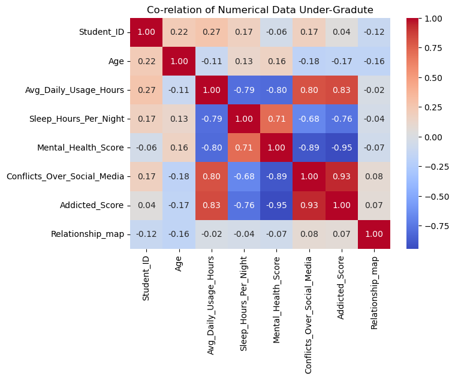

```python
cor_mat=df_cleaned1.select_dtypes(include=['number']).corr()
plt.figure(figsize=(7, 5))
sns.heatmap(data=cor_mat, annot=True, cmap='coolwarm', fmt='0.2f')
plt.title("Co-relation of Numerical Data Under-Gradute")
plt.show()
```

```python
df_male=df_cleaned1[df_cleaned1['Gender']=='Male']
df_male.groupby('Relationship_Status')[['Addicted_Score','Sleep_Hours_Per_Night','Avg_Daily_Usage_Hours','Mental_Health_Score']].mean()
```

| Relationship_Status | Addicted_Score | Sleep_Hours_Per_Night | Avg_Daily_Usage_Hours | Mental_Health_Score |
| --- | --- | --- | --- | --- |
| Complicated | 6.533333 | 6.186667 | 4.253333 | 6.266667 |
| In Relationship | 6.039735 | 7.079470 | 4.619205 | 6.503311 |
| Single | 6.602151 | 6.853226 | 5.040323 | 6.096774 |

```python
df_female=df_cleaned1[df_cleaned1['Gender']=='Female']
df_female.groupby('Relationship_Status')[['Addicted_Score','Sleep_Hours_Per_Night','Avg_Daily_Usage_Hours','Mental_Health_Score']].mean()
```

| Relationship_Status | Addicted_Score | Sleep_Hours_Per_Night | Avg_Daily_Usage_Hours | Mental_Health_Score |
| --- | --- | --- | --- | --- |
| Complicated | 7.470588 | 5.647059 | 5.135294 | 5.647059 |
| In Relationship | 6.673913 | 6.557246 | 5.271739 | 6.072464 |
| Single | 6.323232 | 7.096970 | 4.818687 | 6.292929 |

### From the above we can understand that Male are more in benifit during a stable relationship compared to Female

### While Females have more healthy sleep cycle when they are single

## Using age as a factor and making age group sections

```python
df_cleaned.groupby('Age')[['Addicted_Score','Sleep_Hours_Per_Night','Avg_Daily_Usage_Hours','Mental_Health_Score']].mean()
```

| Age | Addicted_Score | Sleep_Hours_Per_Night | Avg_Daily_Usage_Hours | Mental_Health_Score |
| --- | --- | --- | --- | --- |
| 18 | 7.785714 | 5.535714 | 5.385714 | 5.214286 |
| 19 | 6.650307 | 6.742945 | 5.120245 | 6.055215 |
| 20 | 6.478788 | 6.864848 | 4.930303 | 6.218182 |
| 21 | 6.589744 | 6.868590 | 4.950641 | 6.160256 |
| 22 | 6.095238 | 7.127891 | 4.676190 | 6.476190 |
| 23 | 5.676471 | 6.938235 | 4.508824 | 6.647059 |
| 24 | 6.115385 | 6.850000 | 5.046154 | 6.346154 |

```python
label=['18-20','21-22','23-24']
bins= [17,20,22,24]
df_cleaned['Age Group'] = pd.cut(df_cleaned['Age'], bins=bins,labels=label,right=True)
```

```python
df_cleaned.groupby('Age Group', observed=False)[['Addicted_Score','Avg_Daily_Usage_Hours','Mental_Health_Score']].mean()
```

| Age Group | Addicted_Score | Avg_Daily_Usage_Hours | Mental_Health_Score |
| --- | --- | --- | --- |
| 18-20 | 6.614035 | 5.039474 | 6.099415 |
| 21-22 | 6.349835 | 4.817492 | 6.313531 |
| 23-24 | 5.866667 | 4.741667 | 6.516667 |

##### From the above we can see that students at the age of 18-20 tends to be more addicted and has more screen time that others , We can also see that with age the addiction and screen time gradually decreases

### We need to check which social media platform tends to be more addicctive

```python
most_addictive=df_cleaned.groupby('Most_Used_Platform', observed=False)[['Addicted_Score','Avg_Daily_Usage_Hours','Mental_Health_Score','Sleep_Hours_Per_Night']].mean().sort_values(by='Addicted_Score', ascending=False)
```

```python
most_addictive
```

| Most_Used_Platform | Addicted_Score | Avg_Daily_Usage_Hours | Mental_Health_Score | Sleep_Hours_Per_Night |
| --- | --- | --- | --- | --- |
| WhatsApp | 7.462963 | 6.475926 | 5.537037 | 5.870370 |
| Snapchat | 7.461538 | 5.092308 | 5.538462 | 5.707692 |
| TikTok | 7.428571 | 5.346104 | 5.714286 | 6.362987 |
| Instagram | 6.554217 | 4.872289 | 6.124498 | 7.021285 |
| YouTube | 6.100000 | 4.080000 | 6.600000 | 6.350000 |
| WeChat | 6.066667 | 4.960000 | 6.466667 | 7.360000 |
| KakaoTalk | 6.000000 | 4.725000 | 6.000000 | 7.050000 |
| Facebook | 5.666667 | 4.507317 | 6.715447 | 7.360163 |
| Twitter | 5.500000 | 4.870000 | 6.833333 | 7.106667 |
| VKontakte | 5.000000 | 4.250000 | 7.000000 | 7.750000 |
| LinkedIn | 3.809524 | 2.519048 | 8.000000 | 7.285714 |
| LINE | 3.000000 | 3.250000 | 8.000000 | 8.350000 |

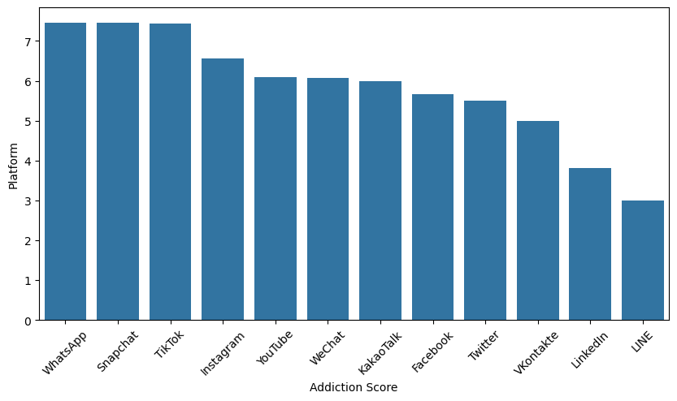

```python
plt.figure(figsize=(10,5))
ax=sns.barplot(data=most_addictive, x='Most_Used_Platform', y='Addicted_Score')
plt.xlabel('Addiction Score')
plt.ylabel('Platform')
plt.xticks(rotation=45)
plt.show()
```

#### As we can see that the top 5 addictive platform mainly consists of Whatsapp, Snapchat, TikTok, Instagram and Youtube

```python
df_cleaned.groupby('Affects_Academic_Performance')[['Addicted_Score','Avg_Daily_Usage_Hours','Sleep_Hours_Per_Night','Mental_Health_Score','Conflicts_Over_Social_Media']].mean()
```

| Affects_Academic_Performance | Addicted_Score | Avg_Daily_Usage_Hours | Sleep_Hours_Per_Night | Mental_Health_Score | Conflicts_Over_Social_Media |
| --- | --- | --- | --- | --- | --- |
| No | 4.595238 | 3.804365 | 7.813095 | 7.424603 | 1.781746 |
| Yes | 7.461369 | 5.538631 | 6.343709 | 5.560706 | 3.443709 |

### It is evident that addiction of social media does effects sleep, mental health, academic performance and relationship conflicts

## Doing a T test for Undergrades, Grades, and HighSchool to learn the usage pattern

```python
from scipy import stats as st
grad_scores = df_cleaned[df_cleaned['Academic_Level'] == 'Graduate']['Addicted_Score']
ugrad_scores = df_cleaned[df_cleaned['Academic_Level'] == 'Undergraduate']['Addicted_Score']

t_stat, p_value = st.ttest_ind(grad_scores, ugrad_scores, equal_var=False)

print("T-statistic:", t_stat)
print("P-value:", p_value)
```

```
T-statistic: -2.0831956439212367
P-value: 0.037608641858322356
```

#### The p value is less than 0.05 but at 5% level so it is true that udergraduate are more addicted but the - value of T stats says that Grads are comparetively less addicted compared to undergrads

```python
high_school = df_cleaned[df_cleaned['Academic_Level']=='High School']['Addicted_Score']
t_stat,p_value=st.ttest_ind(high_school,grad_scores, equal_var=False)
print('T-statstics:', t_stat)
print('P-Value:',p_value)
```

```
T-statstics: 7.736290679543667
P-Value: 5.30198916458155e-09
```

```python
t_stat,p_value=st.ttest_ind(high_school,ugrad_scores, equal_var=False)
print('T-statstics:', t_stat)
print('P-Value:',p_value)
```

```
T-statstics: 6.61290381702445
P-Value: 1.215986030508101e-07
```

```python
df_cleaned.groupby('Academic_Level')[['Addicted_Score','Avg_Daily_Usage_Hours','Sleep_Hours_Per_Night','Mental_Health_Score','Conflicts_Over_Social_Media']].mean().sort_values(by='Addicted_Score', ascending=False)
```

| Academic_Level | Addicted_Score | Avg_Daily_Usage_Hours | Sleep_Hours_Per_Night | Mental_Health_Score | Conflicts_Over_Social_Media |
| --- | --- | --- | --- | --- | --- |
| High School | 8.037037 | 5.544444 | 5.455556 | 5.111111 | 3.740741 |
| Undergraduate | 6.492918 | 5.001416 | 6.828612 | 6.178470 | 2.917847 |
| Graduate | 6.243077 | 4.776923 | 7.030154 | 6.372308 | 2.701538 |

#### We can clearly see the reason why High School students has less mental health score as because they have high addiction.

```python
df_cleaned['Conflicts_Over_Social_Media'].value_counts().head(10)
```

```
Conflicts_Over_Social_Media
3    261
2    204
4    174
1     47
5     15
0      4
Name: count, dtype: int64
```

### as we can check that the class of 0 and 5 is very small it will create an imaba;nce during prediction so I can merge 5 and 4 and merge 1 and 0 togethere thinking 1 conflict in relationship might not be dueto social media usage behaviour

```python
df_cleaned['Conflicts_Over_Social_Media']=df_cleaned['Conflicts_Over_Social_Media'].replace({0:1,5:4})
```

## Trying to Classify relationship conflicts depending upon user pattern and platform.

```python
from sklearn.model_selection import train_test_split
from sklearn.preprocessing import LabelEncoder, StandardScaler
from sklearn.linear_model import LogisticRegression
from sklearn.metrics import classification_report, accuracy_score

lb=LabelEncoder()
df_cleaned['Most_Used_Platform_trans']=lb.fit_transform(df_cleaned['Most_Used_Platform'])

X=df_cleaned[['Most_Used_Platform_trans','Avg_Daily_Usage_Hours','Sleep_Hours_Per_Night','Addicted_Score']]
y=df_cleaned['Conflicts_Over_Social_Media']

sc=StandardScaler()
X_sc=sc.fit_transform(X)

X_train, X_test, y_train, y_test = train_test_split(X_sc, y, test_size=0.2, random_state=42)
```

```python
model=LogisticRegression(multi_class='multinomial', solver='lbfgs',max_iter=500)
model.fit(X_train,y_train)

y_prediction=model.predict(X_test)

print("Accuracy:", accuracy_score(y_prediction,y_test))

print(classification_report(y_prediction,y_test))
```

```
Accuracy: 0.9290780141843972
              precision    recall  f1-score   support

           1       0.55      0.75      0.63         8
           2       0.93      0.89      0.91        45
           3       0.98      0.96      0.97        51
           4       0.97      0.97      0.97        37

    accuracy                           0.93       141
   macro avg       0.86      0.89      0.87       141
weighted avg       0.94      0.93      0.93       141
```

### No we can see that the model has captured the data and made an accuracy of 92 in predicting the relationship conflict depending upon the usage behaviour

### with an impressive f1-score of 97 , 97 , 91 for all the major classes and 63 for the minor class

### Lets move with a pairplot to see which pairs are influecing eachother the most

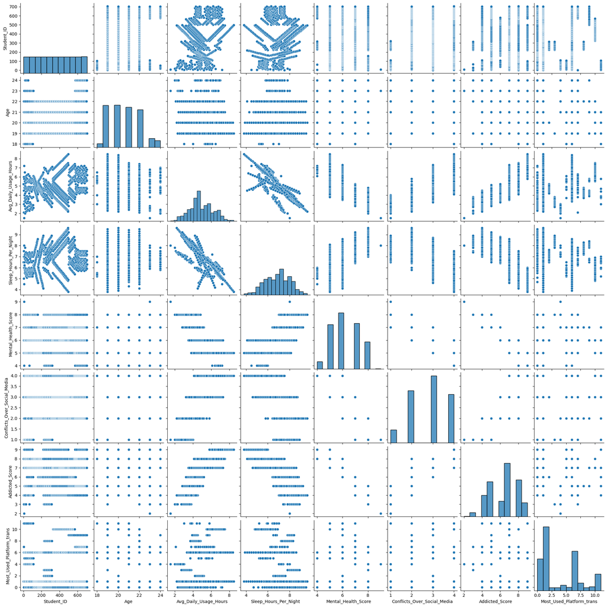

```python
sns.pairplot(df_cleaned)
```

### We can conclude that we have already seen it beforeand there is nothing new to see in this graph

## Clustering the data to find a pattern within

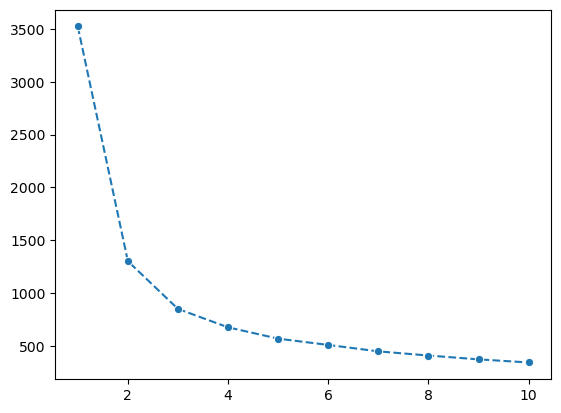

```python
from sklearn.cluster import KMeans
X=df_cleaned[['Mental_Health_Score','Avg_Daily_Usage_Hours','Sleep_Hours_Per_Night','Addicted_Score','Conflicts_Over_Social_Media']]
X_sc=sc.fit_transform(X)

# determining the K using elbow
winthincSquaredSum=[]
k=10
for i in range(1,k+1):
    kmeans=KMeans(n_clusters=i, init='k-means++', random_state=42, n_init=10)
    kmeans.fit(X_sc)
    winthincSquaredSum.append(kmeans.inertia_)

# plotting the graph

plt.figure(figure=(5,5))
ax=sns.lineplot(x= range(1,k+1), y=winthincSquaredSum, marker='o' , linestyle='--')
```

#### from the above elbow method we can understand that 3 clusters will be perfect as the slops has drastic changes from 1 to and then 2 to 3 after that it starts tosmoothen the fall.

```
     so using 3 clusters will  perfectly  segregate the data into meaning full clusters
```

```python
features_for_clustering = [
    'Addicted_Score',
    'Avg_Daily_Usage_Hours',
    'Sleep_Hours_Per_Night',
    'Mental_Health_Score',
    'Conflicts_Over_Social_Media'
]
k=3
kmeans=KMeans(n_clusters=k, init='k-means++', random_state=42, n_init=10)
df_cleaned['Clusters']= kmeans.fit_predict(X_sc)
print(f"\n--- K-Means Clustering with k = {k} ---")
```

```
--- K-Means Clustering with k = 3 ---
```

```python
cluster_center_scaled=pd.DataFrame(kmeans.cluster_centers_,columns=features_for_clustering)
```

```python
cluster_center_scaled=sc.inverse_transform(cluster_center_scaled)
```

```python
cluster_center_scaled=pd.DataFrame(cluster_center_scaled,columns=features_for_clustering)
```

```python
cluster_center_scaled
```

|  | Addicted_Score | Avg_Daily_Usage_Hours | Sleep_Hours_Per_Night | Mental_Health_Score | Conflicts_Over_Social_Media |
| --- | --- | --- | --- | --- | --- |
| 0 | 5.896414 | 4.980080 | 6.792829 | 6.960159 | 3.031873 |
| 1 | 7.400749 | 3.806367 | 7.832584 | 4.674157 | 1.865169 |
| 2 | 4.994652 | 6.424599 | 5.595187 | 8.251337 | 3.951872 |

```python
df_cleaned_no_outliers = df_cleaned.copy()
column_to_check='Avg_Daily_Usage_Hours'
# Calculate Q1 (25th percentile)
Q1 = df_cleaned_no_outliers[column_to_check].quantile(0.25)
# Calculate Q3 (75th percentile)
Q3 = df_cleaned_no_outliers[column_to_check].quantile(0.75)
# Calculate IQR (Interquartile Range)
IQR = Q3 - Q1

lowerbound=Q1-(1.5*IQR)
outerbound=Q3+(1.5*IQR)
```

```python
df_cleaned_no_outliers = df_cleaned_no_outliers[(df_cleaned_no_outliers['Avg_Daily_Usage_Hours'] >= lowerbound) & (df_cleaned_no_outliers['Avg_Daily_Usage_Hours'] <= outerbound)]
```

```python
df_cleaned_no_outliers
```

|  | Student_ID | Age | Gender | Academic_Level | Country | Avg_Daily_Usage_Hours | Most_Used_Platform | Affects_Academic_Performance | Sleep_Hours_Per_Night | Mental_Health_Score | Relationship_Status | Conflicts_Over_Social_Media | Addicted_Score | Age Group | Most_Used_Platform_trans | Clusters |
| --- | --- | --- | --- | --- | --- | --- | --- | --- | --- | --- | --- | --- | --- | --- | --- | --- |
| 0 | 1 | 19 | Female | Undergraduate | Bangladesh | 5.2 | Instagram | Yes | 6.5 | 6 | In Relationship | 3 | 8 | 18-20 | 1 | 0 |
| 1 | 2 | 22 | Male | Graduate | India | 2.1 | Twitter | No | 7.5 | 8 | Single | 1 | 3 | 21-22 | 7 | 1 |
| 2 | 3 | 20 | Female | Undergraduate | USA | 6.0 | TikTok | Yes | 5.0 | 5 | Complicated | 4 | 9 | 18-20 | 6 | 2 |
| 3 | 4 | 18 | Male | High School | UK | 3.0 | YouTube | No | 7.0 | 7 | Single | 1 | 4 | 18-20 | 11 | 1 |
| 4 | 5 | 21 | Male | Graduate | Canada | 4.5 | Facebook | Yes | 6.0 | 6 | In Relationship | 2 | 7 | 21-22 | 0 | 0 |
| ... | ... | ... | ... | ... | ... | ... | ... | ... | ... | ... | ... | ... | ... | ... | ... | ... |
| 700 | 701 | 20 | Female | Undergraduate | Italy | 4.7 | TikTok | No | 7.2 | 7 | In Relationship | 2 | 5 | 18-20 | 6 | 1 |
| 701 | 702 | 23 | Male | Graduate | Russia | 6.8 | Instagram | Yes | 5.9 | 4 | Single | 4 | 9 | 23-24 | 1 | 2 |
| 702 | 703 | 21 | Female | Undergraduate | China | 5.6 | WeChat | Yes | 6.7 | 6 | In Relationship | 3 | 7 | 21-22 | 9 | 0 |
| 703 | 704 | 24 | Male | Graduate | Japan | 4.3 | Twitter | No | 7.5 | 8 | Single | 2 | 4 | 23-24 | 7 | 1 |
| 704 | 705 | 19 | Female | Undergraduate | Poland | 6.2 | Facebook | Yes | 6.3 | 5 | Single | 4 | 8 | 18-20 | 0 | 2 |

702 rows × 16 columns

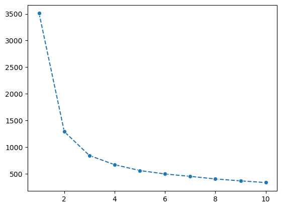

```python
from sklearn.cluster import KMeans
X=df_cleaned_no_outliers[['Mental_Health_Score','Avg_Daily_Usage_Hours','Sleep_Hours_Per_Night','Addicted_Score','Conflicts_Over_Social_Media']]
X_sc=sc.fit_transform(X)

# determining the K using elbow
winthincSquaredSum=[]
k=10
for i in range(1,k+1):
    kmeans=KMeans(n_clusters=i, init='k-means++', random_state=42, n_init=10)
    kmeans.fit(X_sc)
    winthincSquaredSum.append(kmeans.inertia_)

# plotting the graph

plt.figure(figure=(5,5))
ax=sns.lineplot(x= range(1,k+1), y=winthincSquaredSum, marker='o' , linestyle='--')
```

```python
features_for_clustering = [
    'Addicted_Score',
    'Avg_Daily_Usage_Hours',
    'Sleep_Hours_Per_Night',
    'Mental_Health_Score',
    'Conflicts_Over_Social_Media'
]
k=3
kmeans=KMeans(n_clusters=k, init='k-means++', random_state=42, n_init=10)
df_cleaned_no_outliers['Clusters']= kmeans.fit_predict(X_sc)
print(f"\n--- K-Means Clustering with k = {k} ---")
```

```
--- K-Means Clustering with k = 3 ---
```

```python
cluster_center_scaled=pd.DataFrame(kmeans.cluster_centers_,columns=features_for_clustering)
cluster_center_scaled=sc.inverse_transform(cluster_center_scaled)
cluster_center_scaled=pd.DataFrame(cluster_center_scaled,columns=features_for_clustering)
cluster_center_scaled
```

|  | Addicted_Score | Avg_Daily_Usage_Hours | Sleep_Hours_Per_Night | Mental_Health_Score | Conflicts_Over_Social_Media |
| --- | --- | --- | --- | --- | --- |
| 0 | 7.394737 | 3.815038 | 7.831955 | 4.684211 | 1.868421 |
| 1 | 5.900000 | 4.975600 | 6.791200 | 6.960000 | 3.028000 |
| 2 | 4.994624 | 6.401075 | 5.622581 | 8.236559 | 3.951613 |

```python
from sklearn.tree import DecisionTreeClassifier, export_text, plot_tree
X=df_cleaned_no_outliers[['Mental_Health_Score','Avg_Daily_Usage_Hours','Sleep_Hours_Per_Night','Addicted_Score','Conflicts_Over_Social_Media']]
y = pd.qcut(df_cleaned_no_outliers['Addicted_Score'], q=3, labels=[0, 1, 2]) # making the decision drawn mathemetically
tree=DecisionTreeClassifier(max_depth=3, random_state=42)
tree.fit(X,y)
tree_report=export_text(tree, feature_names=features_for_clustering)
tree_report
```

```
'|--- Mental_Health_Score <= 5.50\n|   |--- class: 0\n|--- Mental_Health_Score >  5.50\n|   |--- Mental_Health_Score <= 7.50\n|   |   |--- class: 1\n|   |--- Mental_Health_Score >  7.50\n|   |   |--- class: 2\n'
```

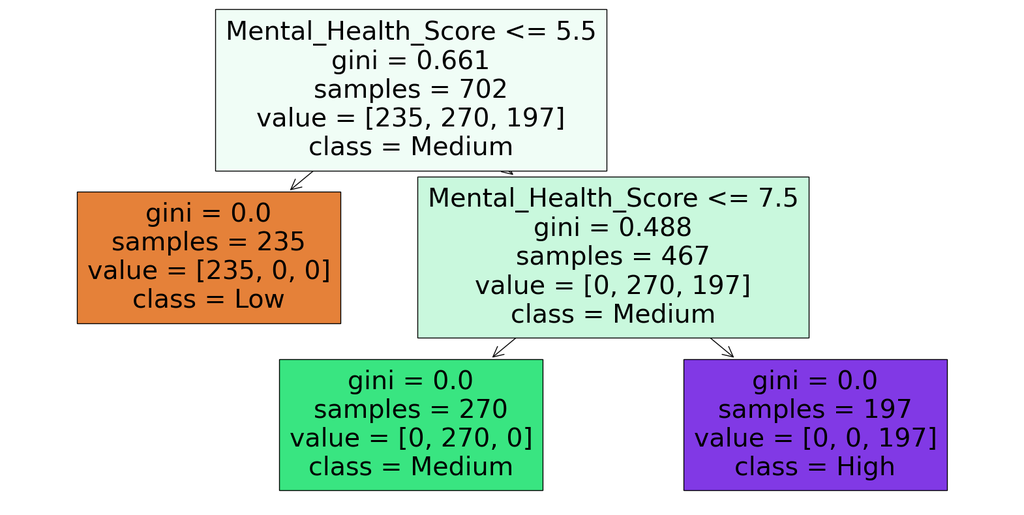

```python
plt.figure(figsize=(20,10))
plot_tree(tree, feature_names=features_for_clustering, class_names=["Low", "Medium", "High"], filled=True)
plt.show()
```

```python
df_cleaned_no_outliers['Clusters1']=tree.predict(X)
```

```python
df_cleaned_no_outliers
```

|  | Student_ID | Age | Gender | Academic_Level | Country | Avg_Daily_Usage_Hours | Most_Used_Platform | Affects_Academic_Performance | Sleep_Hours_Per_Night | Mental_Health_Score | Relationship_Status | Conflicts_Over_Social_Media | Addicted_Score | Age Group | Most_Used_Platform_trans | Clusters | Clusters1 |
| --- | --- | --- | --- | --- | --- | --- | --- | --- | --- | --- | --- | --- | --- | --- | --- | --- | --- |
| 0 | 1 | 19 | Female | Undergraduate | Bangladesh | 5.2 | Instagram | Yes | 6.5 | 6 | In Relationship | 3 | 8 | 18-20 | 1 | 1 | 2 |
| 1 | 2 | 22 | Male | Graduate | India | 2.1 | Twitter | No | 7.5 | 8 | Single | 1 | 3 | 21-22 | 7 | 0 | 0 |
| 2 | 3 | 20 | Female | Undergraduate | USA | 6.0 | TikTok | Yes | 5.0 | 5 | Complicated | 4 | 9 | 18-20 | 6 | 2 | 2 |
| 3 | 4 | 18 | Male | High School | UK | 3.0 | YouTube | No | 7.0 | 7 | Single | 1 | 4 | 18-20 | 11 | 0 | 0 |
| 4 | 5 | 21 | Male | Graduate | Canada | 4.5 | Facebook | Yes | 6.0 | 6 | In Relationship | 2 | 7 | 21-22 | 0 | 1 | 1 |
| ... | ... | ... | ... | ... | ... | ... | ... | ... | ... | ... | ... | ... | ... | ... | ... | ... | ... |
| 700 | 701 | 20 | Female | Undergraduate | Italy | 4.7 | TikTok | No | 7.2 | 7 | In Relationship | 2 | 5 | 18-20 | 6 | 0 | 0 |
| 701 | 702 | 23 | Male | Graduate | Russia | 6.8 | Instagram | Yes | 5.9 | 4 | Single | 4 | 9 | 23-24 | 1 | 2 | 2 |
| 702 | 703 | 21 | Female | Undergraduate | China | 5.6 | WeChat | Yes | 6.7 | 6 | In Relationship | 3 | 7 | 21-22 | 9 | 1 | 1 |
| 703 | 704 | 24 | Male | Graduate | Japan | 4.3 | Twitter | No | 7.5 | 8 | Single | 2 | 4 | 23-24 | 7 | 0 | 0 |
| 704 | 705 | 19 | Female | Undergraduate | Poland | 6.2 | Facebook | Yes | 6.3 | 5 | Single | 4 | 8 | 18-20 | 0 | 2 | 2 |

702 rows × 17 columns

```python
# Now compute the 'cluster center' for each leaf
clasification_limits = df_cleaned_no_outliers.groupby('Clusters1').agg({
    'Addicted_Score':'mean',
    'Avg_Daily_Usage_Hours':'mean',
    'Sleep_Hours_Per_Night':'mean',
    'Mental_Health_Score':'mean',
    'Conflicts_Over_Social_Media':'mean',
    'Clusters1':'count'
}).rename(columns={'Clusters1':'Count'})

clasification_limits
```

| Clusters1 | Addicted_Score | Avg_Daily_Usage_Hours | Sleep_Hours_Per_Night | Mental_Health_Score | Conflicts_Over_Social_Media | Count |
| --- | --- | --- | --- | --- | --- | --- |
| 0 | 4.510638 | 3.771489 | 7.841277 | 7.446809 | 1.787234 | 235 |
| 1 | 6.774074 | 4.943704 | 6.858889 | 6.077778 | 2.940741 | 270 |
| 2 | 8.269036 | 6.234518 | 5.747716 | 4.974619 | 3.934010 | 197 |

```python
df_cleaned_no_outliers.drop('Clusters', axis=1)
```

|  | Student_ID | Age | Gender | Academic_Level | Country | Avg_Daily_Usage_Hours | Most_Used_Platform | Affects_Academic_Performance | Sleep_Hours_Per_Night | Mental_Health_Score | Relationship_Status | Conflicts_Over_Social_Media | Addicted_Score | Age Group | Most_Used_Platform_trans | Clusters1 |
| --- | --- | --- | --- | --- | --- | --- | --- | --- | --- | --- | --- | --- | --- | --- | --- | --- |
| 0 | 1 | 19 | Female | Undergraduate | Bangladesh | 5.2 | Instagram | Yes | 6.5 | 6 | In Relationship | 3 | 8 | 18-20 | 1 | 2 |
| 1 | 2 | 22 | Male | Graduate | India | 2.1 | Twitter | No | 7.5 | 8 | Single | 1 | 3 | 21-22 | 7 | 0 |
| 2 | 3 | 20 | Female | Undergraduate | USA | 6.0 | TikTok | Yes | 5.0 | 5 | Complicated | 4 | 9 | 18-20 | 6 | 2 |
| 3 | 4 | 18 | Male | High School | UK | 3.0 | YouTube | No | 7.0 | 7 | Single | 1 | 4 | 18-20 | 11 | 0 |
| 4 | 5 | 21 | Male | Graduate | Canada | 4.5 | Facebook | Yes | 6.0 | 6 | In Relationship | 2 | 7 | 21-22 | 0 | 1 |
| ... | ... | ... | ... | ... | ... | ... | ... | ... | ... | ... | ... | ... | ... | ... | ... | ... |
| 700 | 701 | 20 | Female | Undergraduate | Italy | 4.7 | TikTok | No | 7.2 | 7 | In Relationship | 2 | 5 | 18-20 | 6 | 0 |
| 701 | 702 | 23 | Male | Graduate | Russia | 6.8 | Instagram | Yes | 5.9 | 4 | Single | 4 | 9 | 23-24 | 1 | 2 |
| 702 | 703 | 21 | Female | Undergraduate | China | 5.6 | WeChat | Yes | 6.7 | 6 | In Relationship | 3 | 7 | 21-22 | 9 | 1 |
| 703 | 704 | 24 | Male | Graduate | Japan | 4.3 | Twitter | No | 7.5 | 8 | Single | 2 | 4 | 23-24 | 7 | 0 |
| 704 | 705 | 19 | Female | Undergraduate | Poland | 6.2 | Facebook | Yes | 6.3 | 5 | Single | 4 | 8 | 18-20 | 0 | 2 |

702 rows × 16 columns

```python
df_cleaned_no_outliers['Clusters1']=df_cleaned_no_outliers['Clusters1'].map({0:'Low', 1:"Moderate",2:'High'})
```

```python
df_cleaned_no_outliers
```

|  | Student_ID | Age | Gender | Academic_Level | Country | Avg_Daily_Usage_Hours | Most_Used_Platform | Affects_Academic_Performance | Sleep_Hours_Per_Night | Mental_Health_Score | Relationship_Status | Conflicts_Over_Social_Media | Addicted_Score | Age Group | Most_Used_Platform_trans | Clusters | Clusters1 |
| --- | --- | --- | --- | --- | --- | --- | --- | --- | --- | --- | --- | --- | --- | --- | --- | --- | --- |
| 0 | 1 | 19 | Female | Undergraduate | Bangladesh | 5.2 | Instagram | Yes | 6.5 | 6 | In Relationship | 3 | 8 | 18-20 | 1 | 1 | High |
| 1 | 2 | 22 | Male | Graduate | India | 2.1 | Twitter | No | 7.5 | 8 | Single | 1 | 3 | 21-22 | 7 | 0 | Low |
| 2 | 3 | 20 | Female | Undergraduate | USA | 6.0 | TikTok | Yes | 5.0 | 5 | Complicated | 4 | 9 | 18-20 | 6 | 2 | High |
| 3 | 4 | 18 | Male | High School | UK | 3.0 | YouTube | No | 7.0 | 7 | Single | 1 | 4 | 18-20 | 11 | 0 | Low |
| 4 | 5 | 21 | Male | Graduate | Canada | 4.5 | Facebook | Yes | 6.0 | 6 | In Relationship | 2 | 7 | 21-22 | 0 | 1 | Moderate |
| ... | ... | ... | ... | ... | ... | ... | ... | ... | ... | ... | ... | ... | ... | ... | ... | ... | ... |
| 700 | 701 | 20 | Female | Undergraduate | Italy | 4.7 | TikTok | No | 7.2 | 7 | In Relationship | 2 | 5 | 18-20 | 6 | 0 | Low |
| 701 | 702 | 23 | Male | Graduate | Russia | 6.8 | Instagram | Yes | 5.9 | 4 | Single | 4 | 9 | 23-24 | 1 | 2 | High |
| 702 | 703 | 21 | Female | Undergraduate | China | 5.6 | WeChat | Yes | 6.7 | 6 | In Relationship | 3 | 7 | 21-22 | 9 | 1 | Moderate |
| 703 | 704 | 24 | Male | Graduate | Japan | 4.3 | Twitter | No | 7.5 | 8 | Single | 2 | 4 | 23-24 | 7 | 0 | Low |
| 704 | 705 | 19 | Female | Undergraduate | Poland | 6.2 | Facebook | Yes | 6.3 | 5 | Single | 4 | 8 | 18-20 | 0 | 2 | High |

702 rows × 17 columns

```python
Cluster_counteries_count=df_cleaned_no_outliers.groupby(['Country','Clusters1']).size()
```

```python
# First, convert the grouped data into a dataframe for easier manipulation
Cluster_counteries_count_df = Cluster_counteries_count.reset_index(name='Count')

# Count number of unique clusters per country
cluster_counts_per_country = Cluster_counteries_count_df.groupby('Country')['Clusters1'].nunique().reset_index(name='Num_Clusters')

# Merge back with original counts
merged_df = Cluster_counteries_count_df.merge(cluster_counts_per_country, on='Country')

# Apply your condition:
filtered_df = merged_df[
    (merged_df['Num_Clusters'] > 1) |
    ((merged_df['Num_Clusters'] == 1) & (merged_df['Count'] > 15))
]

# Display result
filtered_df
```

|  | Country | Clusters1 | Count | Num_Clusters |
| --- | --- | --- | --- | --- |
| 5 | Australia | High | 1 | 2 |
| 6 | Australia | Low | 13 | 2 |
| 11 | Bangladesh | High | 10 | 2 |
| 12 | Bangladesh | Moderate | 10 | 2 |
| 18 | Brazil | High | 1 | 2 |
| 19 | Brazil | Moderate | 7 | 2 |
| 21 | Canada | Low | 1 | 2 |
| 22 | Canada | Moderate | 33 | 2 |
| 24 | China | Low | 7 | 2 |
| 25 | China | Moderate | 9 | 2 |
| 31 | Denmark | Low | 27 | 1 |
| 35 | Finland | High | 1 | 2 |
| 36 | Finland | Low | 7 | 2 |
| 37 | France | Low | 25 | 2 |
| 38 | France | Moderate | 2 | 2 |
| 46 | India | High | 33 | 3 |
| 47 | India | Low | 1 | 3 |
| 48 | India | Moderate | 19 | 3 |
| 51 | Ireland | High | 2 | 2 |
| 52 | Ireland | Moderate | 25 | 2 |
| 54 | Italy | High | 6 | 3 |
| 55 | Italy | Low | 9 | 3 |
| 56 | Italy | Moderate | 6 | 3 |
| 58 | Japan | Low | 21 | 1 |
| 70 | Malaysia | Low | 1 | 2 |
| 71 | Malaysia | Moderate | 7 | 2 |
| 72 | Maldives | High | 10 | 3 |
| 73 | Maldives | Low | 8 | 3 |
| 74 | Maldives | Moderate | 1 | 3 |
| 76 | Mexico | High | 9 | 2 |
| 77 | Mexico | Moderate | 18 | 2 |
| 82 | Nepal | High | 10 | 3 |
| 83 | Nepal | Low | 8 | 3 |
| 84 | Nepal | Moderate | 1 | 3 |
| 85 | Netherlands | Low | 7 | 2 |
| 86 | Netherlands | Moderate | 1 | 2 |
| 87 | New Zealand | Low | 1 | 2 |
| 88 | New Zealand | Moderate | 7 | 2 |
| 93 | Pakistan | High | 8 | 2 |
| 94 | Pakistan | Moderate | 11 | 2 |
| 99 | Poland | High | 8 | 2 |
| 100 | Poland | Low | 8 | 2 |
| 104 | Russia | High | 8 | 2 |
| 105 | Russia | Low | 13 | 2 |
| 112 | South Korea | Low | 1 | 2 |
| 113 | South Korea | Moderate | 12 | 2 |
| 114 | Spain | High | 8 | 2 |
| 115 | Spain | Moderate | 19 | 2 |
| 116 | Sri Lanka | Low | 11 | 2 |
| 117 | Sri Lanka | Moderate | 8 | 2 |
| 119 | Switzerland | Low | 27 | 1 |
| 125 | Turkey | High | 9 | 2 |
| 126 | Turkey | Moderate | 18 | 2 |
| 128 | UK | High | 8 | 3 |
| 129 | UK | Low | 1 | 3 |
| 130 | UK | Moderate | 13 | 3 |
| 131 | USA | High | 30 | 2 |
| 132 | USA | Moderate | 8 | 2 |

```python
cluster_country_proportions = df_cleaned_no_outliers.groupby('Country')['Clusters1'].value_counts(normalize=True).unstack(fill_value=0)
print("\nProportion of students per cluster, by country:")
cluster_country_proportions.head()
```

```
Proportion of students per cluster, by country:
```

| Clusters1 Country | High | Low | Moderate |
| --- | --- | --- | --- |
| Afghanistan | 0.0 | 1.0 | 0.0 |
| Albania | 0.0 | 0.0 | 1.0 |
| Andorra | 1.0 | 0.0 | 0.0 |
| Argentina | 1.0 | 0.0 | 0.0 |
| Armenia | 1.0 | 0.0 | 0.0 |

```python
countries_of_interest = ['India', 'USA', 'UK']

# Filter the dataframe for these countries
selected_countries = cluster_country_proportions.loc[countries_of_interest]
selected_countries1 = filtered_df[filtered_df['Country'].isin(countries_of_interest)]
# Display
print(selected_countries)
selected_countries1.head(10)
```

```
Clusters1      High       Low  Moderate
Country
India      0.622642  0.018868  0.358491
USA        0.789474  0.000000  0.210526
UK         0.363636  0.045455  0.590909
```

|  | Country | Clusters1 | Count | Num_Clusters |
| --- | --- | --- | --- | --- |
| 46 | India | High | 33 | 3 |
| 47 | India | Low | 1 | 3 |
| 48 | India | Moderate | 19 | 3 |
| 128 | UK | High | 8 | 3 |
| 129 | UK | Low | 1 | 3 |
| 130 | UK | Moderate | 13 | 3 |
| 131 | USA | High | 30 | 2 |
| 132 | USA | Moderate | 8 | 2 |

## We have also determined the addiction pattern according to Countries and also found the proportion to easily compare across Countries

### Creating a dashboard to view all the findings

```python
import panel as pn
import pandas as pd
import hvplot.pandas

pn.extension()


# Gender and age filter widgets
gender_options = ['All'] + df_cleaned['Gender'].unique().tolist()
age_options = ['All'] + df_cleaned['Age Group'].unique().tolist()
relationship = ['All']+ df_cleaned['Relationship_Status'].unique().tolist()

gender_select = pn.widgets.Select(name='Select Gender', options=gender_options, value='All')
age_select = pn.widgets.Select(name='Age Group', options=age_options, value='All')
relationship_tag=pn.widgets.Select(name='Relationship Status',options=relationship, value='All')

@pn.depends(selected_gender=gender_select, selected_age=age_select, selected_relationship=relationship_tag)
# Callback function
def update_dashboard(selected_gender, selected_age,selected_relationship ):

    # Filtering logic
    filtered_data = df_cleaned.copy()

    if selected_gender != 'All':
        filtered_data = filtered_data[filtered_data['Gender'] == selected_gender]

    if selected_age != 'All':
        filtered_data = filtered_data[filtered_data['Age Group'] == selected_age]
    if selected_relationship !='All':
        filtered_data=filtered_data[filtered_data['Relationship_Status']==selected_relationship ]

    # Display filtered data
    data_table = pn.pane.DataFrame(filtered_data, width=1200, height=200)

    # fix platform counts
    platform_counts = (
        filtered_data['Most_Used_Platform']
        .value_counts()
        .reset_index()
    )
    platform_counts.columns = ['Platform', 'Count']
    #platform_counts['Platform'] = platform_counts['Platform'].astype(str)
    platform_counts['Platform'] = platform_counts['Platform'].astype(str)

    bar_plot = platform_counts.hvplot.bar(
        x='Platform',
        y='Count',
        color='skyblue',
        title='Most Used Platform',
        width=1200,
        height=400
    )

    return pn.Column(data_table, bar_plot)

# Bind function to widgets
dashboard = pn.bind(update_dashboard, selected_gender=gender_select, selected_age=age_select)

@pn.depends(selected_gender=gender_select, selected_age=age_select, selected_relationship=relationship_tag)
def dashboard2(selected_gender, selected_age,selected_relationship):
     # Filtering logic
    filtered_data = df_cleaned.copy()

    if selected_gender != 'All':
        filtered_data = filtered_data[filtered_data['Gender'] == selected_gender]

    if selected_age != 'All':
        filtered_data = filtered_data[filtered_data['Age Group'] == selected_age]
    if selected_relationship !='All':
        filtered_data=filtered_data[filtered_data['Relationship_Status']==selected_relationship ]

    # Display filtered data
    data_table = pn.pane.DataFrame(filtered_data, width=1200, height=200)

    score_plot = filtered_data.hvplot.box(
        y='Addicted_Score',
        title='Addiction Score Distribution',
        width=500,
        height=400
    )

    # Also show mean addiction score
    mean_score = filtered_data['Addicted_Score'].mean()
    mean_pane = pn.pane.Markdown(f"### Mean Addiction Score: {mean_score:.2f}")

    return pn.Column(mean_pane, score_plot)

@pn.depends(selected_gender=gender_select, selected_age=age_select, selected_relationship=relationship_tag)
def dashboard3(selected_gender, selected_age,selected_relationship):
     # Filtering logic
    filtered_data = df_cleaned.copy()

    if selected_gender != 'All':
        filtered_data = filtered_data[filtered_data['Gender'] == selected_gender]

    if selected_age != 'All':
        filtered_data = filtered_data[filtered_data['Age Group'] == selected_age]
    if selected_relationship !='All':
        filtered_data=filtered_data[filtered_data['Relationship_Status']==selected_relationship ]

    # Display filtered data
    data_table = pn.pane.DataFrame(filtered_data, width=1200, height=200)

    score_plot = filtered_data.hvplot.box(
        y='Mental_Health_Score',
        title='Mental Score Distribution',
        width=500,
        height=400
    )

    # Also show mean addiction score
    mean_score = filtered_data['Mental_Health_Score'].mean()
    mean_pane = pn.pane.Markdown(f"### Mental Health Score: {mean_score:.2f}")

    return pn.Column(mean_pane, score_plot)

@pn.depends(selected_gender=gender_select, selected_age=age_select, selected_relationship=relationship_tag)
def dashboard4(selected_gender, selected_age,selected_relationship):
    filtered_data = df_cleaned.copy()

    if selected_gender != 'All':
        filtered_data = filtered_data[filtered_data['Gender'] == selected_gender]

    if selected_age != 'All':
        filtered_data = filtered_data[filtered_data['Age Group'] == selected_age]
    if selected_relationship !='All':
        filtered_data=filtered_data[filtered_data['Relationship_Status']==selected_relationship ]

    # Display filtered data
    data_table = pn.pane.DataFrame(filtered_data, width=1200, height=200)

    score_plot = filtered_data.hvplot.box(
        y='Conflicts_Over_Social_Media',
        title='Conflicts_Over_Social_Media Distribution Graph',
        width=500,
        height=400
    )

    # Also show mean addiction score
    mean_score = filtered_data['Conflicts_Over_Social_Media'].mean()
    mean_pane = pn.pane.Markdown(f"### SocialMedia Conflicts: {mean_score:.2f}")

    return pn.Column(mean_pane, score_plot)

@pn.depends(selected_gender=gender_select, selected_age=age_select, selected_relationship=relationship_tag)
def dashboard5(selected_gender, selected_age,selected_relationship):
    filtered_data = df_cleaned.copy()

    if selected_gender != 'All':
        filtered_data = filtered_data[filtered_data['Gender'] == selected_gender]

    if selected_age != 'All':
        filtered_data = filtered_data[filtered_data['Age Group'] == selected_age]
    if selected_relationship !='All':
        filtered_data=filtered_data[filtered_data['Relationship_Status']==selected_relationship ]

    # Display filtered data
    data_table = pn.pane.DataFrame(filtered_data, width=1200, height=200)

    score_plot = filtered_data.hvplot.box(
        y='Avg_Daily_Usage_Hours',
        title='Avg_Daily_Usage_Hours',
        width=500,
        height=400
    )

    # Also show mean addiction score
    mean_score = filtered_data['Avg_Daily_Usage_Hours'].mean()
    mean_pane = pn.pane.Markdown(f"### Avg_Daily_Usage_Hours: {mean_score:.2f}")

    return pn.Column(mean_pane, score_plot)

@pn.depends(selected_gender=gender_select, selected_age=age_select, selected_relationship=relationship_tag)
def dashboard6(selected_gender, selected_age,selected_relationship):
    filtered_data=df_cleaned.copy()

    if selected_gender!='All':
        filtered_data=filtered_data[filtered_data['Gender']== selected_gender]
    if selected_age!='All':
        filtered_data=filtered_data[filtered_data['Age Group']== selected_age]
    if selected_relationship !='All':
        filtered_data=filtered_data[filtered_data['Relationship_Status']==selected_relationship ]


    data_table=pn.pane.DataFrame(filtered_data, width=1200, height = 200)

    score_plot=filtered_data.hvplot.box(y='Sleep_Hours_Per_Night', title="Sleep_Hours_Per_Night", width=500,height=400)
    mean_score=filtered_data['Sleep_Hours_Per_Night'].mean()
    mean_pane=pn.pane.Markdown(f"### Sleep_Hours_Per_Night: {mean_score:.2f}")

    return pn.Column(mean_pane, score_plot)

# Full layout
layout = pn.Column(
    pn.pane.Markdown("# Interactive Dashboard for Student Social Media Addiction"),
    gender_select,
    age_select,
    relationship_tag,
    update_dashboard,
    dashboard2,
    dashboard3,
    dashboard4,
    dashboard5,
    dashboard6
)


layout.servable()
layout
```

[output not shown]